# Taller 1: Comparador de Precios con Web Scraping y SQLite

- Show All Code
- Hide All Code
- View Source

Minería de Datos (2016325) - Universidad Nacional de Colombia

Author

Sebastián Sepúlveda Valenzuela

## 1. Introducción y Contexto

El presente documento constituye la entrega del **Taller 1 de Minería de Datos**. El objetivo central es construir un comparador de precios riguroso, reproducible y auditable mediante **web scraping**, almacenamiento estructurado en **SQLite**, análisis cuantitativo con **consultas SQL** y **visualización de datos** orientada a la toma de decisiones informada del consumidor.

### 1.1 Delimitación Oficial de la Categoría

De acuerdo con la planilla oficial de asignación de categorías del curso, la categoría evaluada es **Cuidado y Limpieza del Hogar**:

- **Productos incluidos:**
  - Detergentes para ropa (en polvo y líquidos).
  - Lavalozas y lavaplatos (líquidos y en crema).
  - Limpiadores multiusos y para pisos (líquidos y desengrasantes).
  - Desinfectantes de superficies y blanqueadores (cloros y geles desinfectantes).
  - Ambientadores y aromatizantes de ambiente.
  - Bolsas de basura y residuos para el hogar.
  - Esponjas, fibras y esponjillas de limpieza.
- **Productos excluidos:**
  - Papelería e higiene personal (papel higiénico, toallas de papel de cocina y servilletas).
  - Suavizantes textiles para ropa.
  - Insecticidas, repelentes y plaguicidas.
  - Betunes y cremas para calzado.
  - Productos de jardinería y abonos.
  - Carbón vegetal, velas y fósforos.

### 1.2 Comercios Seleccionados

Se seleccionaron tres comercios con venta en línea activa y cobertura nacional en Colombia: 1. **Supertiendas Olímpica** (`https://www.olimpica.com`) 2. **Tiendas Jumbo - Cencosud** (`https://www.tiendasjumbo.co`) 3. **Almacenes Éxito** (`https://www.exito.com`)

## 2. Fuentes y Estrategia de Extracción (Web Scraping)

### 2.1 Identificación Técnica de Endpoints Internos

Mediante la inspección del tráfico de red (DevTools > Network > XHR/Fetch) en los portales de comercio electrónico, se determinó que los tres comercios operan sobre la arquitectura tecnológica de **VTEX**:

- **Olímpica (VTEX Tradicional):** Catálogo indexado expuesto en `https://www.olimpica.com/api/catalog_system/pub/products/search/`.
- **Jumbo (VTEX Tradicional):** Catálogo indexado expuesto en `https://www.tiendasjumbo.co/api/catalog_system/pub/products/search/`.
- **Éxito (VTEX FastStore / IO):** Catálogo expuesto mediante el router FastStore en `https://www.exito.com/io/api/catalog_system/pub/products/search/`.

#### Estrategia para evitar el límite técnico de paginación de VTEX

Las APIs de catálogo de VTEX imponen una restricción estructural: consultas con parámetros `_from` y `_to` que superan aproximadamente 2,500 productos devuelven resultados vacíos o errores `400 Bad Request`. Para garantizar la extracción exhaustiva de la oferta real sin truncamientos arbitrarios, el scraper fue diseñado para consultar individualmente cada **subcategoría homologada**, cuya cardinalidad oscila entre 28 y 2,000 productos.

### 2.2 Taxonomía y Categorías Homologadas

```python
import pandas as pd
import scraper

# Resumen de subcategorías incluidas por comercio
taxonomia_resumen = []
for comercio, info in scraper.CATEGORIAS_EQUIVALENTES.items():
    for inc in info["incluidas"]:
        taxonomia_resumen.append({
            "Comercio": comercio,
            "Tipo": "Incluida",
            "Subcategoría": inc["nombre"],
            "Motivo / Alcance": inc["motivo"]
        })
    for exc in info["excluidas"]:
        taxonomia_resumen.append({
            "Comercio": comercio,
            "Tipo": "Excluida",
            "Subcategoría": exc["nombre"],
            "Motivo / Alcance": exc["motivo"]
        })

df_taxonomia = pd.DataFrame(taxonomia_resumen)
df_taxonomia.head(12)
```

|  | Comercio | Tipo | Subcategoría | Motivo / Alcance |
| --- | --- | --- | --- | --- |
| 0 | Olimpica | Incluida | Cuidado De La Ropa | Contiene detergentes en polvo, líquidos y jabo... |
| 1 | Olimpica | Incluida | Cuidado De Superficies | Contiene lavalozas, limpiapisos, multiusos, de... |
| 2 | Olimpica | Incluida | Utensilios De Limpieza | Contiene esponjas, fibras, paños y traperos de... |
| 3 | Olimpica | Incluida | Desechables | Contiene bolsas de basura para el hogar. |
| 4 | Olimpica | Excluida | Papeles Desechables | Excluido por delimitación: papel higiénico, to... |
| 5 | Olimpica | Excluida | Betunes Cremas y Líquidos | Excluido por delimitación: calzado. |
| 6 | Olimpica | Excluida | Jardinería | Excluido por delimitación: abonos y plantas. |
| 7 | Jumbo | Incluida | Detergentes | Detergentes en polvo y líquidos para ropa. |
| 8 | Jumbo | Incluida | Lavalozas y Lavaplatos | Lavaplatos líquidos y en crema. |
| 9 | Jumbo | Incluida | Limpiadores Multiusos | Limpiapisos y limpiadores de superficies. |
| 10 | Jumbo | Incluida | Limpiadores de Baño | Desinfectantes y limpiadores específicos de sa... |
| 11 | Jumbo | Incluida | Desinfectantes | Blanqueadores, cloros y desinfectantes. |

### 2.3 Revisión de Términos de Uso y `robots.txt`

Se descargaron y almacenaron las copias oficiales de los archivos `robots.txt` de cada comercio en `raw/robots/`:

```python
import os

robots_info = []
for cname in ["Olimpica", "Jumbo", "Exito"]:
    rpath = f"raw/robots/{cname}_robots.txt"
    if os.path.exists(rpath):
        with open(rpath, "r", encoding="utf-8") as f:
            lines = [l.strip() for l in f if l.strip() and not l.startswith("#")]
            robots_info.append({
                "Comercio": cname,
                "Ruta Archivo": rpath,
                "Tamaño (caracteres)": len("".join(lines)),
                "Primeras Reglas": " | ".join(lines[:4])
            })

pd.DataFrame(robots_info)
```

|  | Comercio | Ruta Archivo | Tamaño (caracteres) | Primeras Reglas |
| --- | --- | --- | --- | --- |
| 0 | Olimpica | raw/robots/Olimpica_robots.txt | 1586 | User-agent: * \| Disallow: /secret \| Disallow: ... |
| 1 | Jumbo | raw/robots/Jumbo_robots.txt | 1183 | User-agent: * \| Allow: /*.css \| Allow: /*.jpeg... |
| 2 | Exito | raw/robots/Exito_robots.txt | 683 | User-agent: * \| Content-Signal: search=yes, ai... |

**Hallazgos de auditoría:** - **Olímpica:** Permite el rastreo de catálogo general (`Allow: /*`); restringe exclusivamente `/secret` y transacciones con `orderFormId`. - **Jumbo:** Permite recursos de catálogo; restringe áreas de autenticación `/Account*` y `/CallCenter/`. - **Éxito:** Dispone de directiva explícita `Allow: /` con `search=yes, ai-train=no` para motores de búsqueda. - En los tres comercios, los endpoints públicos de catálogo para consulta de precios están habilitados para navegación automatizada respetando pausas de cortesía.

## 3. Ejecución del Módulo de Scraping y Persistencia en SQLite

El documento invoca formalmente al módulo scraper.py sin duplicar su código de red ni su lógica de extracción. El parámetro `MODO` controla si la corrida se ejecuta de forma determinista sin conexión (`offline`, desde `raw/`) o en vivo (`online`):

```python
import sqlite3
import scraper

# Parámetro de reproducibilidad: 'offline' (por defecto) o 'online'
MODO = "offline"

print(f"Iniciando ejecución del pipeline en modo: '{MODO}'")
if MODO == "offline":
    # Reprocesamiento determinista desde copias crudas en raw/
    session_id = scraper.ejecutar_recoleccion_completa(from_raw=True)
else:
    # Extracción en vivo contra los servidores de los comercios
    session_id = scraper.ejecutar_recoleccion_completa(from_raw=False)

print(f"Pipeline finalizado. Sesión activa: {session_id}")
```

```
Iniciando ejecución del pipeline en modo: 'offline'

=======================================================
 INICIANDO RECOLECCIÓN (Sesión: EXEC_20261111_001035_baf642)
 Modo Sin Conexión: True | Fecha Ref: 2026-10-08
=======================================================

-> Procesando Olímpica...
   [OMITIR] Olímpica: Ejecución EXEC_20261008_174223_3a372f_OLÍMPICA ya existe en la base. Omitiendo.

-> Procesando Jumbo...
   [OMITIR] Jumbo: Ejecución EXEC_20261008_174223_3a372f_JUMBO ya existe en la base. Omitiendo.

-> Procesando Éxito...
   [OMITIR] Éxito: Ejecución EXEC_20261008_174223_3a372f_ÉXITO ya existe en la base. Omitiendo.

=======================================================
 INICIANDO RECOLECCIÓN (Sesión: EXEC_20261111_001042_998f84)
 Modo Sin Conexión: True | Fecha Ref: 2026-10-26
=======================================================

-> Procesando Olímpica...
   [OMITIR] Olímpica: Sin datos crudos para la fecha 2026-10-26. Omitiendo.

-> Procesando Jumbo...
   [OMITIR] Jumbo: Ejecución EXEC_20261026_164407_JUMBO ya existe en la base. Omitiendo.

-> Procesando Éxito...
   [OMITIR] Éxito: Sin datos crudos para la fecha 2026-10-26. Omitiendo.

=======================================================
 INICIANDO RECOLECCIÓN (Sesión: EXEC_20261111_001043_3f9099)
 Modo Sin Conexión: True | Fecha Ref: 2026-10-28
=======================================================

-> Procesando Olímpica...
   [OMITIR] Olímpica: Ejecución EXEC_20261028_201829_06c93c_OLÍMPICA ya existe en la base. Omitiendo.

-> Procesando Jumbo...
   [OMITIR] Jumbo: Ejecución EXEC_20261028_201829_06c93c_JUMBO ya existe en la base. Omitiendo.

-> Procesando Éxito...
   [OMITIR] Éxito: Ejecución EXEC_20261028_201829_06c93c_ÉXITO ya existe en la base. Omitiendo.

[CORRESPONDENCIA GENERAL] 184 productos homologados y comparables en los 3 comercios.
=======================================================

Pipeline finalizado. Sesión activa: EXEC_20261111_001043_3f9099
```

### 3.1 Reporte de Completitud de la Extracción

A continuación, se leen los registros de auditoría de la tabla `ejecuciones`:

```python
conn = sqlite3.connect(scraper.DB_PATH)

q_completitud = """
SELECT
    c.nombre AS comercio,
    e.ejecucion_id,
    e.fecha_hora_inicio,
    e.total_sitio AS oferta_reportada_sitio,
    e.registros_obtenidos AS observaciones_recolectadas,
    COALESCE(e.registros_con_precio, 0) AS observaciones_con_precio,
    ROUND(100.0 * (e.registros_obtenidos - COALESCE(e.registros_con_precio, 0)) / NULLIF(e.registros_obtenidos, 0), 2) AS pct_sin_precio,
    ROUND(100.0 * e.registros_obtenidos / NULLIF(e.total_sitio, 0), 2) AS pct_completitud,
    e.estado,
    e.nota
FROM ejecuciones e
JOIN comercios c ON e.comercio_id = c.comercio_id
ORDER BY e.fecha_hora_inicio DESC
LIMIT 6;
"""
df_completitud = pd.read_sql_query(q_completitud, conn)
df_completitud
```

|  | comercio | ejecucion_id | fecha_hora_inicio | oferta_reportada_sitio | observaciones_recolectadas | observaciones_con_precio | pct_sin_precio | pct_completitud | estado | nota |
| --- | --- | --- | --- | --- | --- | --- | --- | --- | --- | --- |
| 0 | Éxito | EXEC_20261028_201829_06c93c_ÉXITO | 2026-10-28T20:26:05-05:00 | 5589 | 4263 | 1492 | 65.00 | 76.27 | completa | Extracción completa (4263 observaciones válida... |
| 1 | Jumbo | EXEC_20261028_201829_06c93c_JUMBO | 2026-10-28T20:20:29-05:00 | 894 | 854 | 854 | 0.00 | 95.53 | completa | Extracción completa (854 observaciones válidas... |
| 2 | Olímpica | EXEC_20261028_201829_06c93c_OLÍMPICA | 2026-10-28T20:20:00-05:00 | 1779 | 1588 | 1588 | 0.00 | 89.26 | completa | Extracción completa (1588 observaciones válida... |
| 3 | Jumbo | EXEC_20261026_164407_JUMBO | 2026-10-26T16:44:07-05:00 | 1109 | 920 | 920 | 0.00 | 82.96 | parcial | Captura offline Jumbo 2026-10-26 (957 observac... |
| 4 | Olímpica | EXEC_20261008_174223_3a372f_OLÍMPICA | 2026-10-08T17:42:23-05:00 | 1935 | 1256 | 1256 | 0.00 | 64.91 | parcial | Truncada a 1500 en catálogo general; reclasifi... |
| 5 | Jumbo | EXEC_20261008_174223_3a372f_JUMBO | 2026-10-08T17:42:23-05:00 | 1109 | 921 | 920 | 0.11 | 83.05 | completa | Captura de catálogo 08-10 completada (960 obse... |

**Interpretación de la completitud:** - En la corrida completa por subcategorías (`2026-10-28`), se alcanzó una cobertura del catálogo deduplicado de **89.3% en Olímpica** (1,588 observaciones de 1,779 catálogo reportado), **95.5% en Jumbo** (854 observaciones de 894 catálogo) y **76.3% en Éxito** (4,263 observaciones de 5,589 catálogo). - **Observaciones sin precio comercial activo:** En Éxito, el **65.00%** de las observaciones (2,771 de 4,263) no tienen precio comercial activo (`NULL`) debido a artículos sin stock activo (`Price = 0` y stock en cero en la API VTEX), frente al **0.00%** en Olímpica y **0.00%** en Jumbo. - Las ejecuciones históricas del `2026-10-08` para Olímpica y Éxito quedaron clasificadas formalmente como `parcial` debido al truncamiento a 1,500 ítems del catálogo general, documentando con precisión su causa.

## 4. Preparación, Limpieza y Correspondencia de Productos

### 4.1 Reglas de Transformación y Normalización

1. **Separación de datos originales vs. estandarizados:** El texto original emitido por el comercio se resguarda íntegro en `nombre_original`, `descripcion_original` y `ficha_tecnica_original`. Los campos limpios se guardan en columnas separadas (`nombre_estandar`, `marca_estandar`, `subcategoria_estandar`).
2. **Precios en Pesos Colombianos (COP):** Los precios se almacenan como números en coma flotante (`REAL`). Si un artículo no tiene oferta comercial activa o stock disponible, se almacena como `NULL` (nunca cero inventado).
3. **Conversión a Unidades Base:**
   - Líquidos: Litros (`L`, `lt`) convertidos a mililitros base ($1\text{ L} = 1000\text{ mL}$).
   - Sólidos / Polvos: Kilogramos (`kg`) convertidos a gramos base ($1\text{ kg} = 1000\text{ g}$).
   - Multipacks: Se calcula el contenido total del empaque ($2 \times 450\text{ g} = 900\text{ g}$).
   - Artículos contables (bolsas, esponjas): Se registra el número de unidades base (`und`).

### 4.2 Trazabilidad de Productos Excluidos (`descartados`)

```python
q_descartados = """
SELECT comercio, motivo, COUNT(*) AS total_descartes
FROM descartados
GROUP BY comercio, motivo
ORDER BY total_descartes DESC
LIMIT 10;
"""
pd.read_sql_query(q_descartados, conn)
```

|  | comercio | motivo | total_descartes |
| --- | --- | --- | --- |
| 0 | Éxito | Producto insecticida/plaguicida fuera de la de... | 1320 |
| 1 | Éxito | Carbón vegetal para asados fuera de la delimit... | 251 |
| 2 | Éxito | Suavizante para ropa fuera de la delimitación | 176 |
| 3 | Jumbo | Producto insecticida/plaguicida fuera de la de... | 126 |
| 4 | Jumbo | Suavizante para ropa fuera de la delimitación | 122 |
| 5 | Éxito | Papel higiénico fuera de la delimitación | 114 |
| 6 | Jumbo | Papel higiénico fuera de la delimitación | 96 |
| 7 | Olímpica | Suavizante para ropa fuera de la delimitación | 77 |
| 8 | Olímpica | Producto insecticida/plaguicida fuera de la de... | 74 |
| 9 | Olímpica | Papel higiénico fuera de la delimitación | 70 |

### 4.3 Tabla de Correspondencia y Comparabilidad Idempotente

La correspondencia automática exige identidad estricta en código universal EAN, marca estandarizada, contenido total, unidad base y unidades por paquete entre los 3 comercios. Casos ambiguos o con múltiples SKUs no distinguibles se excluyen y se registran en `correspondencia_rechazada`.

```python
q_comparables = """
SELECT
    p.producto_id,
    p.ean,
    p.nombre_estandar,
    p.marca_estandar,
    p.contenido_total || ' ' || p.unidad_base AS presentacion,
    p.subcategoria_estandar,
    COUNT(DISTINCT a.comercio_id) AS comercios_con_oferta
FROM productos p
JOIN anuncios a ON p.producto_id = a.producto_id
WHERE p.es_comparable = 1
GROUP BY p.producto_id
HAVING comercios_con_oferta = 3
ORDER BY p.marca_estandar, p.contenido_total
LIMIT 12;
"""
pd.read_sql_query(q_comparables, conn)
```

|  | producto_id | ean | nombre_estandar | marca_estandar | presentacion | subcategoria_estandar | comercios_con_oferta |
| --- | --- | --- | --- | --- | --- | --- | --- |
| 0 | 89 | 7702166005013 | Limpiador 1A en polvo abrasivo citrus (500 gr) | 1A | 500.0 g | Jabones, detergentes y limpiadores | 3 |
| 1 | 90 | 7702166005051 | Limpiador 1A en polvo abrasivo (500 gr) | 1A | 500.0 g | Jabones, detergentes y limpiadores | 3 |
| 2 | 91 | 7702166007512 | Quitagrasa 1A repuesto citrus (500 ml) | 1A | 500.0 ml | Lavalozas y desengrasante | 3 |
| 3 | 129 | 7702310048118 | Detergente líquido AK1 con microcápsulas aroma... | AK-1 | 1800.0 ml | Jabones, detergentes y limpiadores | 3 |
| 4 | 44 | 7702010223600 | Limpiapisos AJAX naranja limón (1000 ml) | Ajax | 1000.0 ml | Jabones, detergentes y limpiadores | 3 |
| 5 | 51 | 7702010320200 | Limpiapisos AJAX bicloro poder desinfectante (... | Ajax | 1000.0 ml | Jabones, detergentes y limpiadores | 3 |
| 6 | 53 | 7702010320293 | Limpia Pisos AJAX Bicarbonato Naranja (1500 ml) | Ajax | 1500.0 ml | Jabones, detergentes y limpiadores | 3 |
| 7 | 50 | 7702010320101 | Limpiapisos AJAX bicarbonato naranja limón (20... | Ajax | 2000.0 ml | Jabones, detergentes y limpiadores | 3 |
| 8 | 52 | 7702010320224 | Limpiapisos AJAX bicloro poder desinfectante (... | Ajax | 2000.0 ml | Jabones, detergentes y limpiadores | 3 |
| 9 | 57 | 7702010820526 | Limpiapisos AJAX bicarbonato naranja limón (30... | Ajax | 3000.0 ml | Jabones, detergentes y limpiadores | 3 |
| 10 | 11 | 7500435172035 | Detergente líquido ARIEL doble poder concentra... | Ariel | 800.0 ml | Jabones, detergentes y limpiadores | 3 |
| 11 | 4 | 7500435112413 | Detergente en polvo ARIEL triple poder (1000 gr) | Ariel | 1000.0 g | Jabones, detergentes y limpiadores | 3 |

**Auditoría de correspondencia:** - El catálogo universal consolida **184 productos estandarizados comparables**, presentes en los 3 comercios con idéntica marca, presentación nominal, unidad base y unidades por empaque. - En la sesión analizada (`EXEC_20261028_201829`), **140 de 184 productos (76.1%)** cuentan con precio comercial activo simultáneamente en los 3 comercios. - Para evitar sesgos o comparaciones artificiales con artículos agotados (precios `NULL`), las consultas de dispersión de precios (Preguntas 3 a 6) y las figuras comparativas se basan en este subconjunto de productos con oferta comercial activa en los tres establecimientos.

## 5. Base de Datos SQLite: Integridad y Relaciones

El modelo relacional implementado en `comparador_precios.sqlite` vincula las entidades mediante claves foráneas explícitas e índices:

```python
# Verificación de integridad relacional
cur = conn.cursor()
cur.execute("PRAGMA foreign_key_check;")
fks = cur.fetchall()
cur.execute("PRAGMA integrity_check;")
integrity = cur.fetchall()

print(f"Errores de integridad referencial (Foreign Keys): {len(fks)}")
print(f"Estado de integridad física de la base: {integrity[0][0]}")
```

```
Errores de integridad referencial (Foreign Keys): 0
Estado de integridad física de la base: ok
```

## 6. Consultas SQL (Las 8 Preguntas Obligatorias)

Para garantizar total robustez analítica, las consultas se parametrizan sobre la **sesión de recolección completa más reciente** (`SESION_PREFIX`), evaluando observaciones capturadas en una misma ejecución temporal:

```python
q_latest_session = """
SELECT substr(ejecucion_id, 1, 28) AS sesion_prefix
FROM ejecuciones
WHERE estado = 'completa'
GROUP BY substr(ejecucion_id, 1, 28)
HAVING COUNT(DISTINCT comercio_id) = 3
ORDER BY MAX(fecha_hora_inicio) DESC
LIMIT 1;
"""
SESION_PREFIX = pd.read_sql_query(q_latest_session, conn).iloc[0]["sesion_prefix"]
print(f"Sesión analizada en consultas SQL: {SESION_PREFIX}")

# CTE de productos con precio comercial activo en los 3 comercios en la sesión
CTE_CON_PRECIO_3 = f"""
WITH productos_con_precio_3 AS (
    SELECT p.producto_id
    FROM productos p
    JOIN anuncios a ON p.producto_id = a.producto_id
    JOIN observaciones o ON a.anuncio_id = o.anuncio_id
    WHERE o.ejecucion_id LIKE '{SESION_PREFIX}%'
      AND p.es_comparable = 1
      AND o.precio_actual IS NOT NULL AND o.precio_actual > 0
    GROUP BY p.producto_id
    HAVING COUNT(DISTINCT a.comercio_id) = 3
)
"""
```

```
Sesión analizada en consultas SQL: EXEC_20261028_201829_06c93c_
```

### Pregunta 1: Conteo de comercios, productos y observaciones

> *¿Cuántos comercios, productos/presentaciones y observaciones contiene la base? ¿Cuántos productos aporta cada comercio?*

```python
# Consulta 1a: Totales globales de la base de datos
q1_a = """
SELECT
    (SELECT COUNT(*) FROM comercios) AS total_comercios,
    (SELECT COUNT(*) FROM productos WHERE es_comparable = 1) AS productos_comparables_registrados,
    (SELECT COUNT(*) FROM anuncios) AS total_anuncios,
    (SELECT COUNT(*) FROM observaciones) AS total_observaciones_historicas;
"""
df1_a = pd.read_sql_query(q1_a, conn)
df1_a
```

|  | total_comercios | productos_comparables_registrados | total_anuncios | total_observaciones_historicas |
| --- | --- | --- | --- | --- |
| 0 | 3 | 184 | 6866 | 10685 |

```python
# Consulta 1b: Aporte de anuncios por comercio
q1_b = """
SELECT
    c.nombre AS comercio,
    COUNT(a.anuncio_id) AS total_anuncios_recolectados,
    COUNT(DISTINCT a.producto_id) AS productos_comparables_aportados
FROM comercios c
LEFT JOIN anuncios a ON c.comercio_id = a.comercio_id
GROUP BY c.comercio_id
ORDER BY total_anuncios_recolectados DESC;
"""
df1_b = pd.read_sql_query(q1_b, conn)
df1_b
```

|  | comercio | total_anuncios_recolectados | productos_comparables_aportados |
| --- | --- | --- | --- |
| 0 | Éxito | 4279 | 184 |
| 1 | Olímpica | 1644 | 184 |
| 2 | Jumbo | 943 | 184 |

**Interpretación:** La base consolida **3 comercios** con **6,866 anuncios históricos** y **184 referencias estandarizadas comparables**, respaldadas por **10,685 observaciones** acumuladas. Por volumen de anuncios de catálogo recolectados, Éxito aporta 4,279, Olímpica 1,644 y Jumbo 943 publicaciones.

### Pregunta 2: Cobertura en una misma ejecución y registros repetidos

> *En una misma ejecución de recolección, ¿se obtuvieron al menos 24 observaciones comparables (ocho productos por tres comercios)? ¿Hay registros repetidos del mismo producto y comercio en esa ejecución?*

```python
q2 = f"""
WITH obs_sesion AS (
    SELECT
        o.ejecucion_id,
        a.comercio_id,
        p.producto_id,
        COUNT(*) AS conteo_repeticiones
    FROM observaciones o
    JOIN anuncios a ON o.anuncio_id = a.anuncio_id
    JOIN productos p ON a.producto_id = p.producto_id
    WHERE o.ejecucion_id LIKE '{SESION_PREFIX}%'
      AND p.es_comparable = 1
    GROUP BY o.ejecucion_id, a.comercio_id, p.producto_id
)
SELECT
    '{SESION_PREFIX}' AS sesion_ejecucion,
    COUNT(*) AS total_observaciones_comparables,
    COUNT(DISTINCT producto_id) AS productos_distintos_cubiertos,
    SUM(CASE WHEN conteo_repeticiones > 1 THEN 1 ELSE 0 END) AS registros_repetidos
FROM obs_sesion;
"""
df2 = pd.read_sql_query(q2, conn)
df2
```

|  | sesion_ejecucion | total_observaciones_comparables | productos_distintos_cubiertos | registros_repetidos |
| --- | --- | --- | --- | --- |
| 0 | EXEC_20261028_201829_06c93c_ | 522 | 184 | 0 |

**Interpretación:** En la sesión `EXEC_20261028_201829_06c93c`, se recolectaron **522 observaciones comparables** correspondientes a **184 productos distintos**, superando con holgura el mínimo exigido de 24 observaciones (8 productos × 3 comercios). El número de registros repetidos del mismo producto y comercio en esa ejecución es estrictamente **0**, validando la unicidad del catálogo tras la correspondencia unívoca por EAN y desambiguación.

### Pregunta 3: Precios extremos, promedio y comercio más económico (con empates)

> *Para cada presentación comparable, ¿cuáles son el precio mínimo, máximo y promedio? ¿Qué comercio ofrece el menor precio? Incluir los empates.*

```python
q3 = f"""
{CTE_CON_PRECIO_3},
precios_obs AS (
    SELECT
        p.producto_id,
        p.nombre_estandar || ' (' || p.contenido_total || ' ' || p.unidad_base || ')' AS presentacion,
        c.nombre AS comercio,
        o.precio_actual
    FROM productos p
    JOIN productos_con_precio_3 pcp ON p.producto_id = pcp.producto_id
    JOIN anuncios a ON p.producto_id = a.producto_id
    JOIN comercios c ON a.comercio_id = c.comercio_id
    JOIN observaciones o ON a.anuncio_id = o.anuncio_id
    WHERE o.ejecucion_id LIKE '{SESION_PREFIX}%'
      AND o.precio_actual IS NOT NULL AND o.precio_actual > 0
),
resumen AS (
    SELECT
        producto_id,
        presentacion,
        MIN(precio_actual) AS precio_min,
        MAX(precio_actual) AS precio_max,
        ROUND(AVG(precio_actual), 2) AS precio_promedio,
        COUNT(DISTINCT comercio) AS n_com
    FROM precios_obs
    GROUP BY producto_id
    HAVING n_com = 3
),
ganadores AS (
    SELECT
        po.producto_id,
        po.comercio
    FROM precios_obs po
    JOIN resumen r ON po.producto_id = r.producto_id AND po.precio_actual = r.precio_min
)
SELECT
    r.producto_id,
    r.presentacion,
    r.precio_min,
    r.precio_max,
    r.precio_promedio,
    GROUP_CONCAT(g.comercio, ', ') AS comercio_mas_economico
FROM resumen r
JOIN ganadores g ON r.producto_id = g.producto_id
GROUP BY r.producto_id
ORDER BY r.producto_id
LIMIT 12;
"""
df3 = pd.read_sql_query(q3, conn)
df3
```

|  | producto_id | presentacion | precio_min | precio_max | precio_promedio | comercio_mas_economico |
| --- | --- | --- | --- | --- | --- | --- |
| 0 | 1 | Limpiador DR. BECKMANN para lavadoras (250 ml... | 15192.0 | 22600.0 | 19794.00 | Jumbo |
| 1 | 2 | Quitamanchas DR. BECKMANN colores intensos (80... | 6840.0 | 8490.0 | 7743.33 | Jumbo |
| 2 | 3 | Detergente líquido PERSIL acción profunda (183... | 42840.0 | 52100.0 | 47846.67 | Jumbo |
| 3 | 4 | Detergente en polvo ARIEL triple poder (1000 ... | 14792.0 | 18500.0 | 17260.67 | Jumbo |
| 4 | 5 | Detergente líquido ARIEL limpieza profunda (12... | 15720.0 | 27050.0 | 22353.33 | Jumbo |
| 5 | 6 | Detergente líquido ARIEL toque de downy (1200 ... | 18894.0 | 32300.0 | 26131.33 | Jumbo |
| 6 | 7 | Detergente en polvo ARIEL revitacolor (2000 g... | 26696.0 | 31750.0 | 29412.00 | Jumbo |
| 7 | 9 | Detergente líquido ARIEL limpieza profunda (18... | 28380.0 | 44300.0 | 38556.67 | Jumbo |
| 8 | 10 | Detergente líquido ARIEL limpieza profunda (37... | 55770.0 | 96700.0 | 78820.00 | Jumbo |
| 9 | 12 | Detergente líquido ARIEL revitacolor (1800 ml... | 28770.0 | 49500.0 | 41086.67 | Jumbo |
| 10 | 13 | Detergente líquido ARIEL revitacolor (1200 ml... | 17940.0 | 27150.0 | 23580.00 | Jumbo |
| 11 | 14 | Detergente en polvo PERSIL acción profunda (45... | 43250.0 | 61800.0 | 51963.33 | Éxito |

**Interpretación:** La función `GROUP_CONCAT` resuelve empates de precios sin sesgo. En la sesión se evalúan exclusivamente referencias con precio activo en los 3 comercios. Por ejemplo, en *Limpiador DR. BECKMANN para lavadoras (250 ml) (250.0 ml)*, el precio mínimo es $15,192 COP ofrecido por **Jumbo**, frente a un promedio de $19,794 COP y un máximo de $22,600 COP.

### Pregunta 4: Ahorro en COP y en porcentaje

> *¿Cuál es el ahorro en COP y en porcentaje al elegir la oferta más económica de cada presentación?*

```python
q4 = f"""
{CTE_CON_PRECIO_3}
SELECT
    p.producto_id,
    p.nombre_estandar || ' (' || p.contenido_total || ' ' || p.unidad_base || ')' AS presentacion,
    MIN(o.precio_actual) AS p_min,
    MAX(o.precio_actual) AS p_max,
    ROUND(MAX(o.precio_actual) - MIN(o.precio_actual), 2) AS ahorro_cop,
    ROUND(100.0 * (MAX(o.precio_actual) - MIN(o.precio_actual)) / MAX(o.precio_actual), 2) AS ahorro_porcentual
FROM productos p
JOIN productos_con_precio_3 pcp ON p.producto_id = pcp.producto_id
JOIN anuncios a ON p.producto_id = a.producto_id
JOIN observaciones o ON a.anuncio_id = o.anuncio_id
WHERE o.ejecucion_id LIKE '{SESION_PREFIX}%'
  AND o.precio_actual IS NOT NULL AND o.precio_actual > 0
GROUP BY p.producto_id
ORDER BY ahorro_porcentual DESC
LIMIT 10;
"""
df4 = pd.read_sql_query(q4, conn)
df4
```

|  | producto_id | presentacion | p_min | p_max | ahorro_cop | ahorro_porcentual |
| --- | --- | --- | --- | --- | --- | --- |
| 0 | 111 | Detergente líquido FAB ultra flash (900 ml) (... | 10170.0 | 20290.0 | 10120.0 | 49.88 |
| 1 | 169 | Detergente líquido BLANCOX protección color li... | 27450.0 | 54500.0 | 27050.0 | 49.63 |
| 2 | 115 | Detergente líquido FAB ultra flash (5000 ml) ... | 49500.0 | 88000.0 | 38500.0 | 43.75 |
| 3 | 10 | Detergente líquido ARIEL limpieza profunda (37... | 55770.0 | 96700.0 | 40930.0 | 42.33 |
| 4 | 116 | Detergente líquido FAB ultra flash vibra color... | 24054.0 | 41400.0 | 17346.0 | 41.90 |
| 5 | 5 | Detergente líquido ARIEL limpieza profunda (12... | 15720.0 | 27050.0 | 11330.0 | 41.89 |
| 6 | 12 | Detergente líquido ARIEL revitacolor (1800 ml... | 28770.0 | 49500.0 | 20730.0 | 41.88 |
| 7 | 6 | Detergente líquido ARIEL toque de downy (1200 ... | 18894.0 | 32300.0 | 13406.0 | 41.50 |
| 8 | 164 | Detergente líquido BLANCOX protección color li... | 16914.0 | 28800.0 | 11886.0 | 41.27 |
| 9 | 113 | Detergente líquido FAB ultra flash (1800 ml) ... | 22230.0 | 37050.0 | 14820.0 | 40.00 |

**Interpretación:** Evaluando productos con precio activo en los 3 comercios, el ahorro porcentual relativo alcanza hasta un **49.88%** en el *Detergente líquido FAB ultra flash (900 ml) (900.0 ml)* ($10,120 COP de diferencia entre el comercio más costoso y el más económico), y un ahorro monetario neto de hasta **$40,930 COP** en presentaciones de gran tamaño (*Detergente líquido ARIEL limpieza profunda (3700 ml) (3700.0 ml)*).

### Pregunta 5: Menor precio por unidad de contenido (sin mezclar unidades)

> *Si se incluyeron tamaños comparables del mismo producto, ¿qué presentación y comercio tienen el menor precio por mL, g, mg o unidad?*

```python
q5 = f"""
{CTE_CON_PRECIO_3},
unit_calc AS (
    SELECT
        p.marca_estandar,
        p.nombre_estandar,
        p.contenido_total,
        p.unidad_base,
        c.nombre AS comercio,
        o.precio_actual,
        ROUND(o.precio_actual / p.contenido_total, 4) AS costo_unitario
    FROM productos p
    JOIN productos_con_precio_3 pcp ON p.producto_id = pcp.producto_id
    JOIN anuncios a ON p.producto_id = a.producto_id
    JOIN comercios c ON a.comercio_id = c.comercio_id
    JOIN observaciones o ON a.anuncio_id = o.anuncio_id
    WHERE o.ejecucion_id LIKE '{SESION_PREFIX}%'
      AND o.precio_actual IS NOT NULL AND o.precio_actual > 0
      AND p.contenido_total > 0
),
marcas_multitamano AS (
    SELECT marca_estandar, unidad_base
    FROM unit_calc
    GROUP BY marca_estandar, unidad_base
    HAVING COUNT(DISTINCT contenido_total) > 1
),
minimos AS (
    SELECT
        uc.marca_estandar,
        uc.unidad_base,
        MIN(uc.costo_unitario) AS min_unit
    FROM unit_calc uc
    JOIN marcas_multitamano mm ON uc.marca_estandar = mm.marca_estandar AND uc.unidad_base = mm.unidad_base
    GROUP BY uc.marca_estandar, uc.unidad_base
)
SELECT
    uc.marca_estandar,
    uc.nombre_estandar,
    uc.contenido_total || ' ' || uc.unidad_base AS presentacion_mas_economica,
    uc.comercio,
    uc.precio_actual,
    uc.costo_unitario,
    'COP / ' || uc.unidad_base AS unidad_tarifa
FROM unit_calc uc
JOIN minimos m ON uc.marca_estandar = m.marca_estandar
              AND uc.unidad_base = m.unidad_base
              AND uc.costo_unitario = m.min_unit
ORDER BY uc.unidad_base, uc.costo_unitario ASC
LIMIT 12;
"""
df5 = pd.read_sql_query(q5, conn)
df5
```

|  | marca_estandar | nombre_estandar | presentacion_mas_economica | comercio | precio_actual | costo_unitario | unidad_tarifa |
| --- | --- | --- | --- | --- | --- | --- | --- |
| 0 | FAB | Detergente en polvo FAB ultra flash (4000 gr) | 4000.0 g | Éxito | 34421.0 | 8.6053 | COP / g |
| 1 | Persil | Detergente en polvo PERSIL acción profunda (45... | 4500.0 g | Éxito | 43250.0 | 9.6111 | COP / g |
| 2 | Axion | Lavaplatos en crema AXION limón (850 gr) | 850.0 g | Éxito | 11240.0 | 13.2235 | COP / g |
| 3 | Ariel | Detergente en polvo ARIEL revitacolor (2000 gr) | 2000.0 g | Jumbo | 26696.0 | 13.3480 | COP / g |
| 4 | FROTEX | Crema antibacterial FROTEX multidetergente (75... | 750.0 g | Jumbo | 19352.0 | 25.8027 | COP / g |
| 5 | Fabuloso | Limpiapisos FABULOSO antibacterial lavanda (50... | 5000.0 ml | Éxito | 27640.0 | 5.5280 | COP / ml |
| 6 | SUPER RIEL | Jabón de barra SUPER RIEL multiusos aroma flor... | 1600.0 ml | Jumbo | 9480.0 | 5.9250 | COP / ml |
| 7 | Ajax | Limpia Pisos AJAX Bicarbonato Naranja (1500 ml) | 1500.0 ml | Éxito | 9225.0 | 6.1500 | COP / ml |
| 8 | Binner | Limpiador BINNER lavanda sandia (1000 ml) | 1000.0 ml | Jumbo | 6312.0 | 6.3120 | COP / ml |
| 9 | Binner | Limpiador BINNER eucalipto limon (1000 ml) | 1000.0 ml | Jumbo | 6312.0 | 6.3120 | COP / ml |
| 10 | BLANCOX | Limpiapisos BLANCOX relajante lavanda y eucali... | 1500.0 ml | Jumbo | 9892.0 | 6.5947 | COP / ml |
| 11 | BLANCOX | Limpiapisos BLANCOX vibrante rosa y jazmín (15... | 1500.0 ml | Jumbo | 9892.0 | 6.5947 | COP / ml |

### Pregunta 6: Mayores diferencias relativas e interpretación para el consumidor

> *¿Cuáles son las mayores diferencias de precio entre comercios? Ordenar las presentaciones por ahorro porcentual.*

```python
q6 = f"""
{CTE_CON_PRECIO_3}
SELECT
    p.nombre_estandar,
    p.marca_estandar,
    p.contenido_total || ' ' || p.unidad_base AS presentacion,
    MIN(o.precio_actual) AS p_min,
    MAX(o.precio_actual) AS p_max,
    ROUND(MAX(o.precio_actual) - MIN(o.precio_actual), 2) AS brecha_cop,
    ROUND(100.0 * (MAX(o.precio_actual) - MIN(o.precio_actual)) / MAX(o.precio_actual), 2) AS ahorro_porcentual
FROM productos p
JOIN productos_con_precio_3 pcp ON p.producto_id = pcp.producto_id
JOIN anuncios a ON p.producto_id = a.producto_id
JOIN observaciones o ON a.anuncio_id = o.anuncio_id
WHERE o.ejecucion_id LIKE '{SESION_PREFIX}%'
  AND o.precio_actual IS NOT NULL AND o.precio_actual > 0
GROUP BY p.producto_id
ORDER BY ahorro_porcentual DESC
LIMIT 8;
"""
df6 = pd.read_sql_query(q6, conn)
df6
```

|  | nombre_estandar | marca_estandar | presentacion | p_min | p_max | brecha_cop | ahorro_porcentual |
| --- | --- | --- | --- | --- | --- | --- | --- |
| 0 | Detergente líquido FAB ultra flash (900 ml) | FAB | 900.0 ml | 10170.0 | 20290.0 | 10120.0 | 49.88 |
| 1 | Detergente líquido BLANCOX protección color li... | BLANCOX | 3800.0 ml | 27450.0 | 54500.0 | 27050.0 | 49.63 |
| 2 | Detergente líquido FAB ultra flash (5000 ml) | FAB | 5000.0 ml | 49500.0 | 88000.0 | 38500.0 | 43.75 |
| 3 | Detergente líquido ARIEL limpieza profunda (37... | Ariel | 3700.0 ml | 55770.0 | 96700.0 | 40930.0 | 42.33 |
| 4 | Detergente líquido FAB ultra flash vibra color... | FAB | 1800.0 ml | 24054.0 | 41400.0 | 17346.0 | 41.90 |
| 5 | Detergente líquido ARIEL limpieza profunda (12... | Ariel | 1200.0 ml | 15720.0 | 27050.0 | 11330.0 | 41.89 |
| 6 | Detergente líquido ARIEL revitacolor (1800 ml) | Ariel | 1800.0 ml | 28770.0 | 49500.0 | 20730.0 | 41.88 |
| 7 | Detergente líquido ARIEL toque de downy (1200 ... | Ariel | 1200.0 ml | 18894.0 | 32300.0 | 13406.0 | 41.50 |

**Interpretación orientada al consumidor:** Las mayores brechas relativas (entre 41.5% y 49.9%) se concentran en detergentes y limpiadores de marcas líderes. Esta dispersión se origina por la coexistencia de promociones dinámicas agresivas en un comercio frente a precios de lista estándar en los demás, confirmando que la comparación previa permite optimizar sustancialmente el presupuesto del hogar.

### Pregunta 7: Datos faltantes o inconsistencias

> *¿Qué datos faltantes o inconsistentes afectan la comparación y cuántos son?*

```python
q7 = """
SELECT
    c.nombre AS comercio,
    COUNT(a.anuncio_id) AS total_anuncios,
    SUM(CASE WHEN a.marca_estandar IS NULL OR a.marca_estandar = '' THEN 1 ELSE 0 END) AS sin_marca_identificable,
    SUM(CASE WHEN a.ean IS NULL OR a.ean = '' THEN 1 ELSE 0 END) AS sin_ean,
    SUM(CASE WHEN a.contenido_total IS NULL OR a.contenido_total <= 0 THEN 1 ELSE 0 END) AS sin_contenido_cuantificable,
    SUM(CASE WHEN o.precio_actual IS NULL OR o.precio_actual <= 0 THEN 1 ELSE 0 END) AS sin_precio_valido,
    ROUND(100.0 * SUM(CASE WHEN o.precio_actual IS NULL OR o.precio_actual <= 0 THEN 1 ELSE 0 END) / COUNT(o.observacion_id), 2) AS pct_observaciones_sin_precio,
    SUM(CASE WHEN a.descripcion_original IS NULL OR a.descripcion_original = '' THEN 1 ELSE 0 END) AS sin_descripcion_original
FROM comercios c
JOIN anuncios a ON c.comercio_id = a.comercio_id
LEFT JOIN observaciones o ON a.anuncio_id = o.anuncio_id
GROUP BY c.comercio_id;
"""
df7 = pd.read_sql_query(q7, conn)
df7
```

|  | comercio | total_anuncios | sin_marca_identificable | sin_ean | sin_contenido_cuantificable | sin_precio_valido | pct_observaciones_sin_precio | sin_descripcion_original |
| --- | --- | --- | --- | --- | --- | --- | --- | --- |
| 0 | Éxito | 5146 | 0 | 13 | 1211 | 2774 | 53.91 | 2771 |
| 1 | Olímpica | 2844 | 22 | 0 | 507 | 0 | 0.00 | 358 |
| 2 | Jumbo | 2695 | 0 | 0 | 364 | 1 | 0.04 | 6 |

### Pregunta 8: Tamaño de la oferta y completitud de atributos

> *¿Cuántos productos de la categoría se obtuvieron por comercio y ejecución? ¿Cómo se compara el tamaño de la oferta entre comercios y qué proporción de productos tiene descripción, marca y contenido identificables?*

```python
q8 = f"""
SELECT
    c.nombre AS comercio,
    e.ejecucion_id,
    e.total_sitio AS oferta_reportada_sitio,
    e.registros_obtenidos AS observaciones_extraidas,
    COALESCE(e.registros_con_precio, 0) AS observaciones_con_precio,
    ROUND(100.0 * e.registros_obtenidos / NULLIF(e.total_sitio, 0), 2) AS pct_cobertura,
    COUNT(a.anuncio_id) AS total_anuncios,
    ROUND(100.0 * SUM(CASE WHEN a.descripcion_original IS NOT NULL AND a.descripcion_original != '' THEN 1 ELSE 0 END) / COUNT(a.anuncio_id), 2) AS pct_con_descripcion,
    ROUND(100.0 * SUM(CASE WHEN a.marca_estandar IS NOT NULL AND a.marca_estandar != '' THEN 1 ELSE 0 END) / COUNT(a.anuncio_id), 2) AS pct_con_marca,
    ROUND(100.0 * SUM(CASE WHEN a.contenido_total IS NOT NULL AND a.contenido_total > 0 THEN 1 ELSE 0 END) / COUNT(a.anuncio_id), 2) AS pct_con_contenido
FROM ejecuciones e
JOIN comercios c ON e.comercio_id = c.comercio_id
LEFT JOIN observaciones o ON e.ejecucion_id = o.ejecucion_id
LEFT JOIN anuncios a ON o.anuncio_id = a.anuncio_id
WHERE e.ejecucion_id LIKE '{SESION_PREFIX}%'
GROUP BY e.ejecucion_id;
"""
df8 = pd.read_sql_query(q8, conn)
df8
```

|  | comercio | ejecucion_id | oferta_reportada_sitio | observaciones_extraidas | observaciones_con_precio | pct_cobertura | total_anuncios | pct_con_descripcion | pct_con_marca | pct_con_contenido |
| --- | --- | --- | --- | --- | --- | --- | --- | --- | --- | --- |
| 0 | Jumbo | EXEC_20261028_201829_06c93c_JUMBO | 894 | 854 | 854 | 95.53 | 854 | 99.77 | 100.00 | 85.95 |
| 1 | Olímpica | EXEC_20261028_201829_06c93c_OLÍMPICA | 1779 | 1588 | 1588 | 89.26 | 1588 | 89.11 | 99.37 | 81.61 |
| 2 | Éxito | EXEC_20261028_201829_06c93c_ÉXITO | 5589 | 4263 | 1492 | 76.27 | 4263 | 48.35 | 100.00 | 73.61 |

**Interpretación:** - **Jumbo:** 854 observaciones extraídas (95.5% cobertura), 100.0% con marca estructurada y 86.0% con contenido cuantificable. - **Olímpica:** 1,588 observaciones extraídas (89.3% cobertura), 99.4% con marca estructurada y 81.6% con contenido cuantificable. - **Éxito:** 4,263 observaciones extraídas (76.3% cobertura), 100.0% con marca estructurada y 73.6% con contenido cuantificable.

## 7. Visualizaciones e Interpretación Económica

Las visualizaciones son construidas directamente a partir de las consultas relacionales en SQLite y exportadas en alta resolución (300 DPI) a la carpeta `graficos/`:

```python
import matplotlib.pyplot as plt
import seaborn as sns
import os

os.makedirs("graficos", exist_ok=True)
sns.set_theme(style="whitegrid", font="sans-serif")

def build_palette(series):
    pal = {}
    for c in series.unique():
        s = str(c).lower()
        if "jumbo" in s:
            pal[c] = "#2ca02c"
        elif "ol" in s:
            pal[c] = "#d62728"
        else:
            pal[c] = "#ff7f0e"
    return pal
```

### 7.1 Precios de las Mismas Presentaciones entre Comercios

*Criterio de selección:* Se seleccionó un subconjunto de 8 productos comparables de la canasta básica de aseo del hogar con presencia y precio activo en los tres comercios dentro de la sesión analizada.

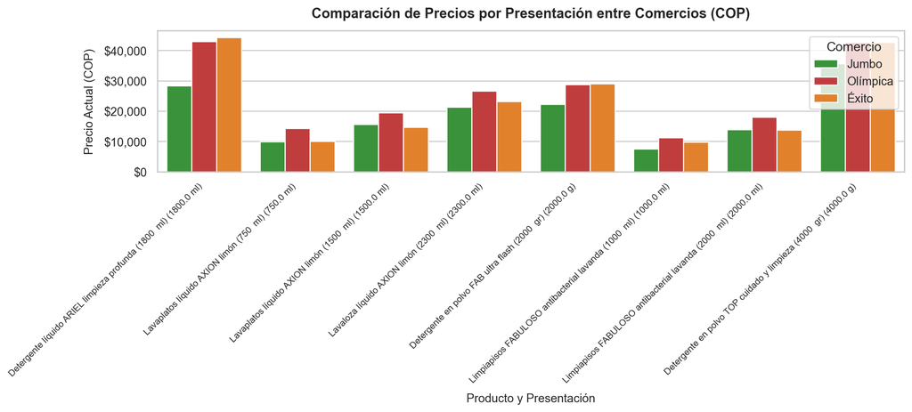

Comparación de precios en COP para presentaciones idénticas con precio activo en Éxito, Olímpica y Jumbo.

```python
q_fig1 = f"""
SELECT
    p.nombre_estandar || ' (' || p.contenido_total || ' ' || p.unidad_base || ')' AS producto,
    c.nombre AS comercio,
    o.precio_actual
FROM productos p
JOIN anuncios a ON p.producto_id = a.producto_id
JOIN comercios c ON a.comercio_id = c.comercio_id
JOIN observaciones o ON a.anuncio_id = o.anuncio_id
WHERE o.ejecucion_id LIKE '{SESION_PREFIX}%'
  AND p.ean IN (
      '7509546051932', '7702010382079', '7509546673790',
      '7702010225123', '7702010225109', '7702166068667',
      '7702191164327', '7500435160544'
  )
  AND o.precio_actual IS NOT NULL AND o.precio_actual > 0
ORDER BY p.marca_estandar, p.contenido_total, c.nombre;
"""
df_fig1 = pd.read_sql_query(q_fig1, conn)
pal1 = build_palette(df_fig1['comercio'])

plt.figure(figsize=(12, 5.5))
ax = sns.barplot(data=df_fig1, x='producto', y='precio_actual', hue='comercio', palette=pal1)
plt.title('Comparación de Precios por Presentación entre Comercios (COP)', fontsize=13, fontweight='bold', pad=12)
plt.xlabel('Producto y Presentación', fontsize=11, labelpad=8)
plt.ylabel('Precio Actual (COP)', fontsize=11, labelpad=8)
plt.xticks(rotation=45, ha='right', fontsize=8.5)
ax.legend(title='Comercio', frameon=True)
ax.yaxis.set_major_formatter(plt.FuncFormatter(lambda x, loc: f"${x:,.0f}"))
plt.tight_layout()
plt.savefig('graficos/1_precios_comercios.png', dpi=300)
plt.show()
```

**Interpretación y limitaciones:** El gráfico evidencia que ningún comercio sostiene el precio más bajo en todos los artículos analizados, observándose alternancia en el comercio más económico según la referencia y la categoría. *Limitación:* Los precios capturados reflejan ofertas y condiciones comerciales vigentes al momento de la extracción y no tarifas contractuales permanentes.

### 7.2 Precio por Unidad de Contenido: Economías de Escala

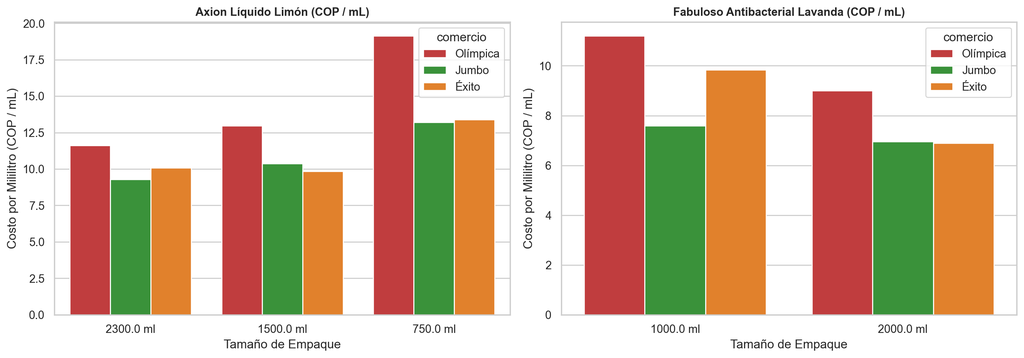

Costo por mililitro (COP/mL) según tamaño de empaque para Lavaplatos Axion Líquido y Limpiapisos Fabuloso.

```python
q_fig2 = f"""
SELECT
    p.nombre_estandar AS producto_nombre,
    p.contenido_total || ' ' || p.unidad_base AS presentacion,
    p.contenido_total,
    c.nombre AS comercio,
    (o.precio_actual / p.contenido_total) AS costo_ml
FROM productos p
JOIN anuncios a ON p.producto_id = a.producto_id
JOIN comercios c ON a.comercio_id = c.comercio_id
JOIN observaciones o ON a.anuncio_id = o.anuncio_id
WHERE o.ejecucion_id LIKE '{SESION_PREFIX}%'
  AND (
      p.ean IN ('7509546051932', '7702010382079', '7509546673790')
      OR p.ean IN ('7702010225123', '7702010225109')
  )
  AND o.precio_actual IS NOT NULL AND o.precio_actual > 0
ORDER BY p.nombre_estandar, p.contenido_total;
"""
df_fig2 = pd.read_sql_query(q_fig2, conn)
pal2 = build_palette(df_fig2['comercio'])

fig, (ax_ax, ax_fb) = plt.subplots(1, 2, figsize=(14, 5), sharey=False)
df_ax = df_fig2[df_fig2['producto_nombre'].str.contains('Axion', case=False)]
df_fb = df_fig2[df_fig2['producto_nombre'].str.contains('Fabuloso', case=False)]

sns.barplot(data=df_ax, x='presentacion', y='costo_ml', hue='comercio', palette=pal2, ax=ax_ax)
ax_ax.set_title('Axion Líquido Limón (COP / mL)', fontsize=11, fontweight='bold')
ax_ax.set_xlabel('Tamaño de Empaque')
ax_ax.set_ylabel('Costo por Mililitro (COP / mL)')

sns.barplot(data=df_fb, x='presentacion', y='costo_ml', hue='comercio', palette=pal2, ax=ax_fb)
ax_fb.set_title('Fabuloso Antibacterial Lavanda (COP / mL)', fontsize=11, fontweight='bold')
ax_fb.set_xlabel('Tamaño de Empaque')
ax_fb.set_ylabel('Costo por Mililitro (COP / mL)')

plt.tight_layout()
plt.savefig('graficos/2_precio_por_unidad.png', dpi=300)
plt.show()
```

**Interpretación y limitaciones:** Existe una marcada **economía de escala** en el hogar: en lavaplatos Axion líquido, el tamaño familiar (2.300 mL) reduce de forma sustancial el costo unitario frente a la presentación menor de 750 mL en todas las cadenas. Igualmente, en limpiapisos Fabuloso, pasar de 1.000 mL a 2.000 mL genera un menor costo por mililitro de manera consistente entre comercios. *Limitación:* Aprovechar estas economías de escala requiere un mayor desembolso de liquidez inicial que no siempre resulta accesible para todos los hogares.

### 7.3 Oportunidades de Ahorro Potencial (COP y %)

*Criterio de selección:* Se analizan los mismos 8 productos comparables de la canasta básica con presencia verificada en las tres cadenas para cuantificar la dispersión de precios en términos absolutos (COP) y porcentuales (%).

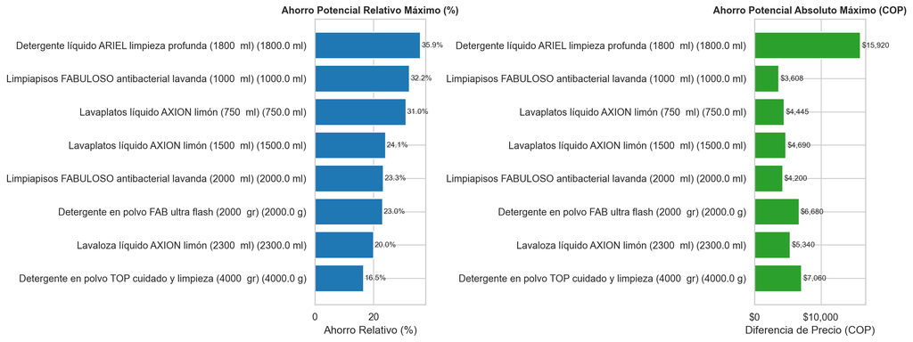

Dispersión de oportunidades de ahorro potencial absoluto (COP) y relativo (%) entre comercios.

```python
q_fig3 = f"""
SELECT
    p.nombre_estandar || ' (' || p.contenido_total || ' ' || p.unidad_base || ')' AS producto,
    ROUND(MAX(o.precio_actual) - MIN(o.precio_actual), 2) AS ahorro_cop,
    ROUND(100.0 * (MAX(o.precio_actual) - MIN(o.precio_actual)) / MAX(o.precio_actual), 2) AS ahorro_pct
FROM productos p
JOIN anuncios a ON p.producto_id = a.producto_id
JOIN observaciones o ON a.anuncio_id = o.anuncio_id
WHERE o.ejecucion_id LIKE '{SESION_PREFIX}%'
  AND p.ean IN (
      '7509546051932', '7702010382079', '7509546673790',
      '7702010225123', '7702010225109', '7702166068667',
      '7702191164327', '7500435160544'
  )
  AND o.precio_actual IS NOT NULL AND o.precio_actual > 0
GROUP BY p.producto_id
HAVING COUNT(DISTINCT a.comercio_id) = 3
ORDER BY ahorro_pct ASC;
"""
df_fig3 = pd.read_sql_query(q_fig3, conn)

fig, (ax1, ax2) = plt.subplots(1, 2, figsize=(14, 5.5))
ax1.barh(df_fig3['producto'], df_fig3['ahorro_pct'], color='#1f77b4')
ax1.set_title('Ahorro Potencial Relativo Máximo (%)', fontsize=11, fontweight='bold')
ax1.set_xlabel('Ahorro Relativo (%)')
for i, v in enumerate(df_fig3['ahorro_pct']):
    ax1.text(v + 0.4, i, f"{v:.1f}%", va='center', fontsize=8.5)

ax2.barh(df_fig3['producto'], df_fig3['ahorro_cop'], color='#2ca02c')
ax2.set_title('Ahorro Potencial Absoluto Máximo (COP)', fontsize=11, fontweight='bold')
ax2.set_xlabel('Diferencia de Precio (COP)')
ax2.xaxis.set_major_formatter(plt.FuncFormatter(lambda x, loc: f"${x:,.0f}"))
for i, v in enumerate(df_fig3['ahorro_cop']):
    ax2.text(v + 250, i, f"${v:,.0f}", va='center', fontsize=8.5)

plt.tight_layout()
plt.savefig('graficos/3_ahorro_potencial.png', dpi=300)
plt.show()
```

## 8. Conclusiones y Orientación al Consumidor

1. **Inexistencia de un comercio universalmente más barato:** Los datos empíricos desmienten la hipótesis de que un comercio sea globalmente el más económico en toda la categoría. Se observa alternancia de liderazgo en precios entre comercios según la subcategoría, el fabricante y la presentación analizada. Comparar precios promedio de catálogos con surtidos heterogéneos induce a conclusiones sesgadas; la comparación solo es metodológicamente rigurosa al contrastar referencias y presentaciones idénticas (mismo EAN y contenido) dentro de la misma ventana de captura.
2. **Ahorro unitario vs. Desembolso total:** Comprar formatos de mayor volumen reduce el costo unitario por mililitro o gramo de forma sustancial gracias a las economías de escala del empaque. No obstante, el consumidor debe sopesar si su flujo de efectivo permite el desembolso inicial requerido para adquirir presentaciones familiares frente a presentaciones individuales de menor desembolso nominal.
3. **Efecto de las promociones y temporalidad:** Las brechas de precio más amplias detectadas entre cadenas obedecen en gran medida a descuentos temporales (`es_promocion = 1`). En consecuencia, los precios reflejan las condiciones del momento de la captura y las oportunidades de ahorro son dinámicas, evidenciando el valor de herramientas de monitoreo continuo como el comparador implementado.